# 20220324作業練習1

請自行用一款合理的勝率賠率模擬人生，決定下注比例，畫出三款人生情境的模擬~ 交易人生人生交易哲學~ 200字以上 (言之有物多多益善)

# 人生情境模擬設定：

- 情境： 有利可圖
- 勝率 ： 40%
- 賠率 ： 2
- 期望淨利： 20%
- 投注比例：固定比例 或 浮動比例「因我認為人生是多變的，因多變而精彩」

```r
init=1    #初始資金
nbet=100  #賭局次數
```

```r
cap=init  #累計資金
pwin=0.4  #勝率
plose= 1-pwin
odds=2  #賠率
f=0.05     #下注比例

for(k in 2:(nbet+1)){
  if(cap[k-1]>=0) {
    outcome = sample(c(-1,odds),prob=c(plose,pwin),1,)
    cap[k]=cap[k-1]*(1+outcome*f)
  }else{
    cap[k]=cap[k-1]
  }
}

plot(cap,type="l",col="blue",lwd=1,
     xlab=paste("nbet ",nbet),
     main=paste0("Fixed Bid:",f*100,"%; ","WinRate: ",pwin*100,"% ; ","Odds: ",odds))
abline(h=tail(cap,1),col="red",lty=2)
```

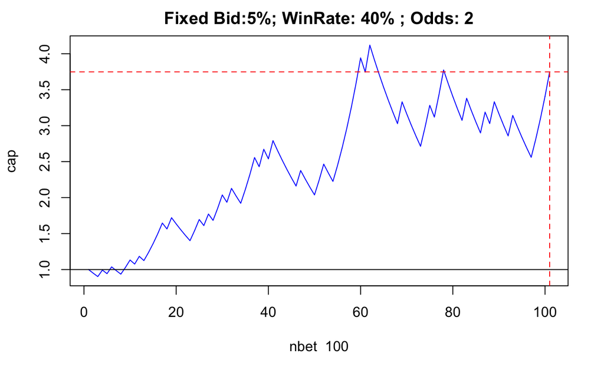

```r
abline(v=nbet+1,col="red",lty=2)
abline(h=1,col="black",lty=1)
```

# **墨守成規**，細水長流。

這張圖採用「固定的投注比例」：5%，即100場賭局，投注比例皆為百分之五，不會出現變化。

在這個瞬息萬變的時代，一昧的墨守成規，難以突破自我，達到更上一層樓的功效。但它卻相對的安全，能夠守住本錢，賺的碎銀三兩。

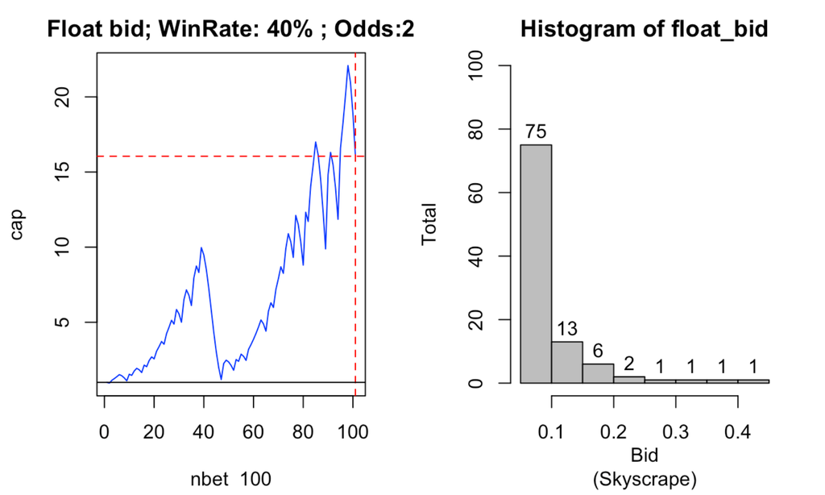

```r
cap=init  #累計資金
pwin=0.4  #勝率
plose= 1-pwin
odds=2  #賠率

f=0.05     #下注比例
float_bid <-c()

for(k in 2:(nbet+1)){
  if(cap[k-1]>=0) {
    float_bid[k]=f
    outcome = sample(c(-1,odds),prob=c(plose,pwin),1,)
    cap[k]=cap[k-1]*(1+outcome*f)
    if(outcome==-1) f = f + 0.05
    if(outcome==odds) f = 0.05
  }else{
    cap[k]=cap[k-1]
  }
}

par(mfrow = c(1,2))
plot(cap,type="l",col="blue",lwd=1,
     xlab=paste("nbet ",nbet),
     main=paste0("Float bid; ","WinRate: ",pwin*100,"% ; ","Odds:",odds))
abline(h=tail(cap,1),col="red",lty=2)
abline(v=nbet+1,col="red",lty=2)
abline(h=1,col="black",lty=1)
hist(float_bid,xlab="Bid\n(Skyscrape)",ylim=c(0,nbet),ylab="Total",label=TRUE,col="gray")
```

# 山重水復疑無路，柳暗花明又一村！

左圖採用「浮動的投注比例」，以5%為基底，採摩天大樓投注法，輸衝（加碼投注5%），贏縮（投注比例為5%）。

右圖則顯示不同投注比例直方圖，即在100次賭局中不同投注比例所出現的次數。

從左圖可知，從0到100次賭局，在第30次第時候翻了五倍，這遠比「墨守成規」所帶來的效益要高。在約莫第40次時，由於浮動投注方式所帶來的風險，使其「腰斬」！累計收益跌落至接近最初始的狀態。然而，死地而後生，在約45次時引來了上漲的趨勢，其間也存在下跌的情況，在約95次時迎來了頂峰，翻了21倍！但最終結果則是翻了16倍。

總而言之，人生是多變，拒絕墨守成規，也許會給你帶來巨大的打擊，正如同在生活中所遭受苦難，要相信這只是暫時的，擁有堅韌之力，必能看見曙光。

```r
cap=init  #累計資金
pwin=0.4  #勝率
plose= 1-pwin
odds=2  #賠率

f=0.05     #下注比例
float_bid <-c()

for(k in 2:(nbet+1)){

  if(cap[k-1]>=0) {
    float_bid[k]=f
    outcome = sample(c(-1,odds),prob=c(plose,pwin),1,)
    cap[k]=cap[k-1]*(1+outcome*f)
    if(outcome==-1){
      f = 2*f
      if(f>1) f=1
    }
    if(outcome==odds) f = 0.05
  }else{
    cap[k]=cap[k-1]
  }
}

par(mfrow = c(1,2))
plot(cap,type="l",col="blue",lwd=1,
     xlab=paste("nbet ",nbet),
     main=paste0("Float bid; ","WinRate: ",pwin*100,"% ; ","Odds:",odds))
abline(h=tail(cap,1),col="red",lty=2)
```

```r
abline(v=nbet+1,col="red",lty=2)
abline(h=1,col="black",lty=1)
```

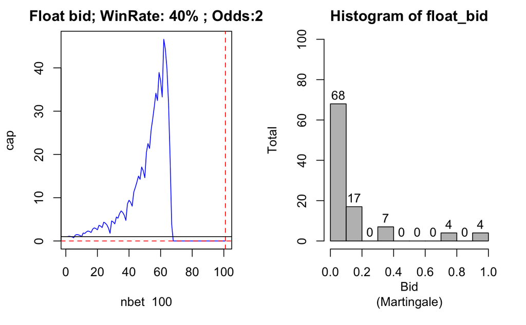

```r
hist(float_bid,xlab="Bid\n(Martingale)",ylim=c(0,nbet),ylab="Total",label=TRUE,col="gray")
```

# 會當凌絕頂，一覽眾「山小」！

左圖採用「浮動的投注比例」，以5%為基底，採馬丁格爾投注法，輸衝（投注比例翻倍），贏縮（投注比例為5%）。

右圖則顯示不同投注比例直方圖，即在100次賭局中不同投注比例所出現的次數。

從右圖可知，投注比例曾高達100%，這意味著輸了即傾家蕩產，此後人生便籠罩著陽光後的陰霾。

雖說極端的方式會帶來兩極化的偏差，但正是這種偏差帶來了極大的收益。

就好比20世紀美蘇冷戰，最為典型的則是太空競賽，1957年蘇聯成功發射世界第一顆人造衛星史潑尼克1號，而美國則不甘示弱，則在1969年發射成功阿波羅11號將太空人送上了月球。

太空競賽促進了科技的發展，同時也增加了在教育科研發展領域的支出，促進了衍生技術的發展。

「這些技術被應用於廚房，交通系統，體育運動，以及現代生活中的其他方面。如今，在地球軌道有上千個人造衛星，在行星周圍傳遞著通訊數據，為使用國提供天氣、植物和人類活動的遙感數據。除此之外，為日常生活中的活動提供燃能量的很多微型技術，從計時到聽音樂，這些研究最初都是在太空競賽的驅動下完成的。」

所以，如若壯志凌雲，不如放膽一試，也許前路迢迢，但我相信志者定能披荊斬棘，哪怕最後傷痕累累。

參考：[https://zh.wikipedia.org/wiki/太空競賽](https://zh.wikipedia.org/wiki/%E5%A4%AA%E7%A9%BA%E7%AB%B6%E8%B3%BD)